# Literature Review

# Literature Review Approach

Citation indexing services collects and maintains a large collection of research literatures from various sources. The most popular citation indexing services are Web Of Science (WoS) from Clarivate, Scopus from Reed Elsevier and Google Scholar. All services provides multidisciplinary citation indexing (Michael Norris, 2007).

There are numerous articles published to compare these services, primarily in terms of coverage and influence. The author do not intend to discuss the comparison in this document. However, it is worth noting that that Google Scholar provides a larger collection of citations of all areas, while WoS and Scopus provides similar results (Martín-Martín, 2018). The drawback of using Google Scholar in this review is the capabilities for exporting citation search results due to Google’s agreement limitations with publishers.  
Web of Science (WoS) is used in data collection as it maintains a reasonably updated index of published literature (estimated at around 4-8 weeks) from various databases, provides an ease of use interface, more importantly search results can be downloaded into tab delimited values (TSV) data files.  
All citation indexing service provides allow users to perform advanced search on attributes such as topic, author, research areas, date of publication, etc. Users can also expand the search results to include relevant articles based on citation references. Whist this can be quite effective for manual research, the refined search may inadvertently filter out some literature of interest. The goal for the initial research is to cover a broad range of literature, therefore author opted by searching only topic via pattern (simple regular expression) and a set of logical operators. Search criteria is shown below:

- Highlighting automation: [automat*] AND;
- Highlighting industry: [building or construction or “civil engineering” or architecture] AND;
- Highlighting regulation: [“building code” OR “construction code” OR compliance OR regulat*] AND;
- Highlighting action: check or validat* or audit*

[interactive chart not shown]

*Search results are loaded with 465 articles.*

## Distribution by Web Of Science Categories

The **Web Of Science** library finely categorises research literature, where each literature may reside in multiple categories. The analysis for which is done via separate categories (as each of the document will contain), then counting unique articles.

**Top 10 categories from search result**

| Research Area | Number of Literatures | Average Citations |
| --- | --- | --- |
| Engineering, Civil | 88 | 20 |
| Construction &amp; Building Technology | 61 | 22 |
| Engineering, Electrical &amp; Electronic | 61 | 16 |
| Computer Science, Interdisciplinary Applications | 51 | 19 |
| Computer Science, Information Systems | 44 | 10 |
| Computer Science, Artificial Intelligence | 29 | 13 |
| Engineering, Multidisciplinary | 26 | 12 |
| Computer Science, Software Engineering | 24 | 10 |
| Mathematical &amp; Computational Biology | 22 | 14 |
| Computer Science, Theory &amp; Methods | 21 | 10 |

## Data Scope

The search results has a broader scope intentionally, including all conference articles, published journal papers, books and others. To perform author analysis, only published journal paper will be considered. This is to ensure that the comparison differentiates contribution using the same baseline. The other reason is that to confidently identify author, both author initials and article identifier (Digital Object ID) are required, and only published journals articles contains such information. As the goal is to understand high level contributions and thematics of study, the scope should contain sufficient information to accomplish set goal.

In addition, the analysis considers only primary authors that has both published papers and also been referenced in the search results. Authors who has been referenced in the search result but with no publications may have been contributing to other domains. For example, H-Score has been discussed and referenced in this article, however it doesn’t necessarily contribute to the area of ACC. On the other hand, if author has published paper in the search result but have not been cited. There maybe 2 possibilities:

1. The author has published paper that has not (yet) contributed to the body of knowledge; or may have contributed to other areas;
2. The paper in the search result may have been a false positive in the search result. This can happen as the search scope is general and broad.

By applying the above criteria, 172 authors from the results has been filtered out, or roughly 40%`. While this seemed to be high, it can be proven the assumption is correct. In the 172 authors, only 28 authors in the search results where the paper are related to AEC (Architecture, Engineering and Construction). The top cited papers from these authors are actually related in a different area in the domain. (See Table 1 for the top 10 authors and respective papers)

[interactive table not shown]

## Scoring

Identify influential authors requiring modelling a comparative impact scale. Jorge Hirsch, presented h-index in 2005, aims to provide a simplistic and objective measure (Ball, 2005). On top of h-index Joe, Egghe proposed g-index which aims at further improvement. (Egghe, 2006). Both of are ranking based methodology calculating top-n articles (reversely sorted by citations) where a function of n equates to a function of citations over total articles. For instance, h-index describes top-h articles where h is less than the number of citations of paper h, on the other hand g-index describes top-g articles where g2 is less than the cumulative sum of the citation. To fairly represent authors work full list of article in their research areas are expected to be retrieved, the limitation however is to look at author’s work in a more specialised area. While influential authors may still have a higher ranking due to he number of publications, however it will become more difficult to differentiate contributions. On the another hand, authors who typically research in more broader areas that has contributed to the industry may have a very low index.

Table 2 shows top 10 authors out of 641 authors in the search result, note that the 10th authors publications is 2, therefore that we can assume most of the authors in the domain will have a h-score/g-score of less than 2, far from differentiating influential authors. Thus, an alternative measure needs to be used.

**Top 10 authors from search result**

| Author | Number of Literatures | Total Citations |
| --- | --- | --- |
| Zhong BT | 7 | 200 |
| Zhang JS | 5 | 239 |
| Nawari NO | 4 | 71 |
| Zhou P | 4 | 81 |
| Monteiro PT | 3 | 63 |
| Soliman J | 3 | 8 |
| Xue XR | 3 | 6 |
| Beach TH | 2 | 50 |
| Beal J | 2 | 67 |
| Bloch T | 2 | 49 |

Simplistically, total citations as a means of measure maybe reasonable as the subset of domain specific data should not introduce objectivity issues the previous scoring methods aimed to solve. However, it may not fairly represent quality and contribution provided through time. For instance, Ethymios A. Delis, et al. described a general approach to identify any violations against Life Safety Code (Delis, 1995). The system “consists of a rule-based system, a frame-based system, and a set of geometric algorithms.” This paper is published in 1995, comparatively highest cited paper pre-2010 in ACC. In the paper, the author explored areas on how objects and relationships can be presented, how rules can be translated into programming language LISP and how geometric algorithms are used to elicit information from shapes captured. Whilst still relevant today, some of the key component has already improved over time, in terms data capturing Building Information Modelling (BIM) took off in the 2010s that streamlined construction project and enabled rich data capture for building objects (David Bryde, 2013), advances in natural language processing paves way for extracting regulatory requirements ((Jiansong Zhang, 2012) for automation.

The author propose to score authors in scope based on total citations factored with diminishing contributions based on the recency of article:

$S = \sum_{i=1}^{n}\alpha^{\delta}{C}_i$

Where the score S is the score, which is a sum of citations C, factored by coefficient to the power of - years since paper was published. In the analysis, of 0.9 is used, describing that an article 10% less significant compared previous year. Using this method, it can be seen that authors contribute more to recent articles are ranked higher, and ranking are more spread out as compared to using h-score/g-score. Top 10 authors are shown below (Table 3):

| Author | Score | Total Citations |
| --- | --- | --- |
| Cherkasov A | 350 | 904 |
| Zhang JS | 116 | 239 |
| Zhong BT | 104 | 200 |
| Huang WX | 90 | 209 |
| Mansouri K | 65 | 110 |
| Chandrasekaran S | 62 | 245 |
| Marzband M | 55 | 103 |
| Brenna M | 48 | 138 |
| Malinowski P | 48 | 112 |
| Solihin W | 44 | 102 |

## Author Citation Network Analysis

To identify sub-domains of study, cross reference between authors are used to understand communities formed. Typically authors are specialised in one domain of study, the aforementioned search criteria should have already restricted to articles of interest. To understand influential authors can help better understand core studies in each of the communities in comparison of looking at cross citation relationship between literatures.

```
## [1] "150 communities found.."
```

```
## [1] "142 verticies filtered out"
```

```
## [1] "35  louvain communities found.."
```

[interactive chart not shown]

```
##                  id     label value citations
## Zhong BT   Zhong BT  Zhong BT    13       200
## Zhang JS   Zhang JS  Zhang JS    18       239
## Nawari NO Nawari NO Nawari NO    13        71
## Zhou P       Zhou P    Zhou P    16        81
## Xue XR       Xue XR    Xue XR     8         6
## Beach TH   Beach TH  Beach TH    15        50
##        from        to weight
## 1  Zhong BT  Zhong BT      8
## 2  Zhong BT  Zhang JS      8
## 3  Zhang JS  Zhang JS      4
## 4  Zhong BT Nawari NO      1
## 5  Zhang JS Nawari NO      7
## 6 Nawari NO Nawari NO      6
```

[interactive chart not shown]

A quick text analysis was conducted summarise key themes authors from each community is concerned with. Top 15 highest bi-grams (2 words) having the highest TF-IDF (Robinson, 2017) are selected for each of the communities with 5 or more members. By looking at bi-grams for each of group, we are able to establish a general theme of the topics revolving these author communities.

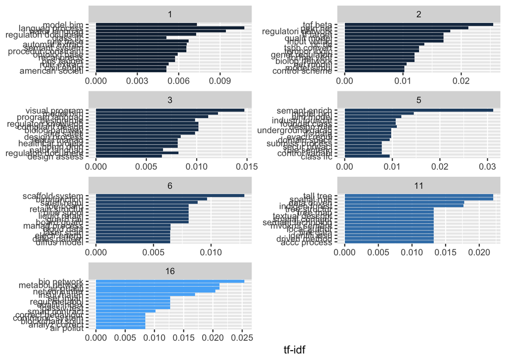

With a bit of further textual analysis, themes for each of the community can be summarised below:

[output not shown]

| Community | Sentences |
| --- | --- |
| 1 | Automated compliance checking (ACC) of building designs requires automated extraction of information from building information models (BIMs).To address this limitation, this paper proposes a new unifi… |
| 2 | Results: We propose a new technique for constructing and analysing qualitative models of genetic regulatory networks based on the Petri net formalism.In this paper, we will motivate the application of… |
| 3 | Development of automated building code compliance checking systems requires appropriate representations for building codes.Although the method of automatic rule checking can effectively identify the c… |
| 5 | The purpose of this study is to develop an automated system that designers and owners can check the evacuation regulation compliance of BIM data.This study reports on the requirements for developing c… |
| 6 | This paper proposed automatic safety rule compliance approach for excavation works leveraging algorithmic modeling tools and BIM technologies.However, building information modelling (BIM) has been mos… |
| 11 | The aim of the study is to create building information modeling based automated building regulation compliance checking software (BIMTRAC3) for municipality users, thereby providing an automated code … |

**Top 10 keywords for isolated communities**

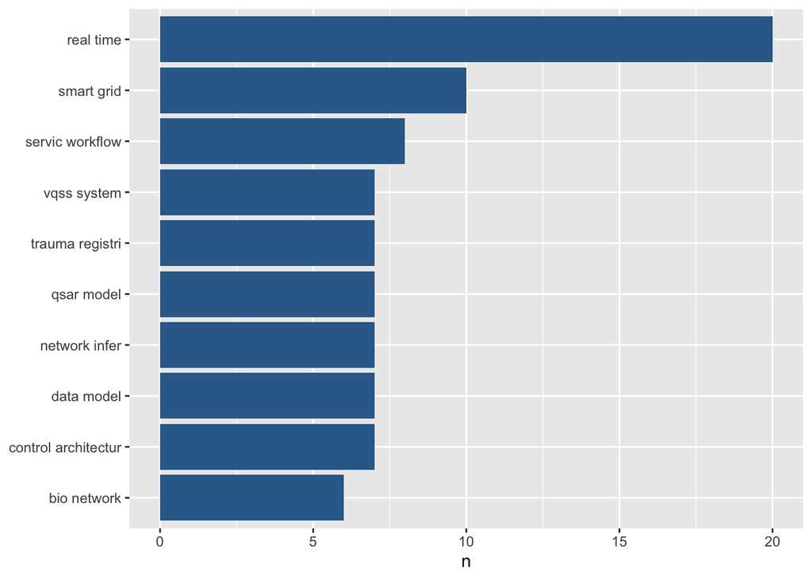

**Wordcloud for for isolated communities**

[interactive chart not shown]

```
##                  id     label value citations group
## Zhong BT   Zhong BT  Zhong BT   104       200     1
## Zhang JS   Zhang JS  Zhang JS   116       239     1
## Nawari NO Nawari NO Nawari NO    38        71     1
## Zhou P       Zhou P    Zhou P    41        81     1
## Soliman J Soliman J Soliman J     6         8     3
## Xue XR       Xue XR    Xue XR     4         6     1
##          from        to weight
## 1 Altintas YD    Choi J      1
## 2 Altintas YD     Gao H      1
## 3 Altintas YD   Ilal SM      1
## 4 Altintas YD Malsane S      2
## 5 Altintas YD  Olsson O      1
## 6 Altintas YD   Yang QZ      1
```

[interactive chart not shown]